# Santa Barbara Urchins

Devin Ngo

10/25/2021

# Introduction

This data explores the size frequency distribution of red and purple sea urchins recorded by Santa Barbara Coastal Long Term Ecological Research program divers at long-term kelp removal experiment sites. The kelp removal experiment started in 2008 at selected reef sites along the Santa Barbara Channel mainland coast.

**Data Citation:** Reed, D. 2020. SBC LTER: Reef: Long-term experiment: Kelp removal: Urchin size frequency distribution ver 20. Environmental Data Initiative. https://doi.org/10.6073/pasta/5a1e9ef03aa47bd2225c0bb98a02a63b.

# Setup

```r
knitr::opts_chunk$set(echo = TRUE, message = FALSE, warning = FALSE)

# Attach Packages
library(tidyverse)
library(here)
library(janitor)
library(kableExtra)
library(lubridate)
```

# Read in Urchins Data

```r
# Read in Data
urchins <- read_csv(here("data", "urchins.csv")) %>%
  clean_names()
```

For reference, the first 6 lines of the data set are shown below:

```r
# Return the first 6 lines
head(urchins)
```

```
## # A tibble: 6 × 6
##   date     site  treatment  size scientific_name               common_name
##   <chr>    <chr> <chr>     <dbl> <chr>                         <chr>
## 1 10/10/08 NAPL  CONTROL     2.5 Strongylocentrotus purpuratus Purple Urchin
## 2 10/10/08 NAPL  CONTROL     2.5 Strongylocentrotus purpuratus Purple Urchin
## 3 10/10/08 NAPL  CONTROL     2.5 Strongylocentrotus purpuratus Purple Urchin
## 4 10/10/08 NAPL  CONTROL     2.5 Strongylocentrotus purpuratus Purple Urchin
## 5 10/10/08 NAPL  CONTROL     2.5 Strongylocentrotus purpuratus Purple Urchin
## 6 10/10/08 NAPL  CONTROL     2.5 Strongylocentrotus purpuratus Purple Urchin
```

# Section 1: Size Comparisons of Purple and Red Urchins

## Data Visualization

Comparing the distribution of sizes between purple and red urchins with a finalized, faceted histogram.

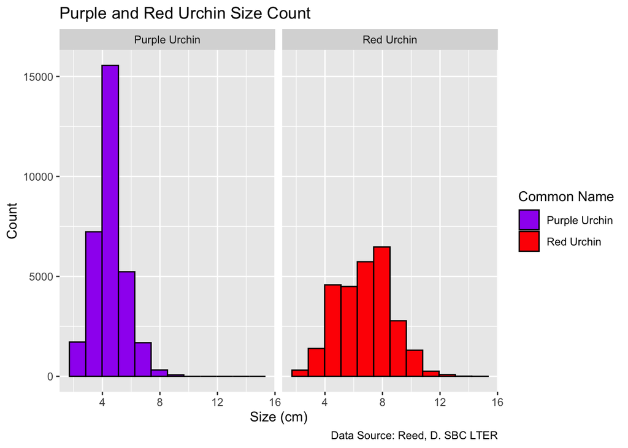

```r
ggplot(data = urchins,
       aes(x = size)) +
  geom_histogram(bins = 12, aes(fill = common_name), color = "black") +
  facet_wrap(~common_name) +
  scale_fill_manual(values = c("purple", "red")) +
  labs(x = "Size (cm)",
       y = "Count",
       title = "Purple and Red Urchin Size Count",
       caption = "Data Source: Reed, D. SBC LTER",
       fill = "Common Name") +
  theme_gray()
```

**Figure 1. Purple and Red Sea Urchin Size Distribution.** Totaling the counts of purple and red urchins by size. Sizes were taken from the urchin diameter (cm), measured to the nearest 0.5 cm.

## Descriptive Data Table

Creating a finalized summary table that contains the following statistics for purple and red urchins: mean, median, standard deviation, and sample size.

```r
urchins_summary <- urchins %>%
  group_by(common_name) %>%
  summarize (mean_size = round(mean(size),3),
             median_size = round(median(size),3),
             sd_size = round(sd(size),3),
             n = n()) %>%
  kable(col.names = c("Species",
                      "Mean Size (cm)",
                      "Median Size (cm)",
                      "Standard Deviation of Size (cm)",
                      "Sample Size (n)")) %>%
  kable_styling(full_width = FALSE)

urchins_summary
```

| Species | Mean Size (cm) | Median Size (cm) | Standard Deviation of Size (cm) | Sample Size (n) |
| --- | --- | --- | --- | --- |
| Purple Urchin | 4.470 | 4.5 | 1.175 | 31805 |
| Red Urchin | 6.776 | 7.0 | 1.891 | 27408 |

**Figure 2. Purple and Red Sea Urchin Size Statistics Summary Table.** This table includes the mean, median, standard deviation, and sample sizes of purple and red sea urchins.

**Takeaways:** Based on the graph and table above, the red urchin seems to display a normal distribution while the purple urchin also seems to be a normal distribution, but possibly skewed in the positive direction. The red sea urchin has a much larger mean and median size, while also having a larger standard deviation, so its results are more spread apart. The difference between the two means is 2.306, giving a percent difference of ~41%, which is large.

# Section 2: Explore Purple Urchin Counts by Site and Year

## Data Wrangling

Creating a subset of the urchins data

```r
# In a piped sequence, creating a stored subset of the urchins data called purple_urchins in which it is: filtered to only include observations for purple urchins, converted the date to class “Date”, created a new column that only contains the year, and created a new column called site_full that contains the full name for each of the five sites.

purple_urchins <- urchins %>%
  filter(common_name %in% c("Purple Urchin")) %>%
  mutate(date_class = mdy(date)) %>%
  mutate(year = year(date_class)) %>%
  mutate(site_full = case_when(
    site == "NAPL" ~ "Naples Reef",
    site == "AQUE" ~ "Arroyo Quemado Reef",
    site == "CARP" ~ "Carpinteria Reef",
    site == "MOHK" ~ "Mohawk Reef",
    site == "IVEE" ~ "Isla Vista Reef"))
```

```r
# Writing code to store a table containing the total number of purple urchins observed by site and year.

purple_urchins_summary <- purple_urchins %>%
  count(site_full, year)
```

## Data Visualization

Making a finalized graph of counts of purple urchins recorded at each site over time for the years included in the study.

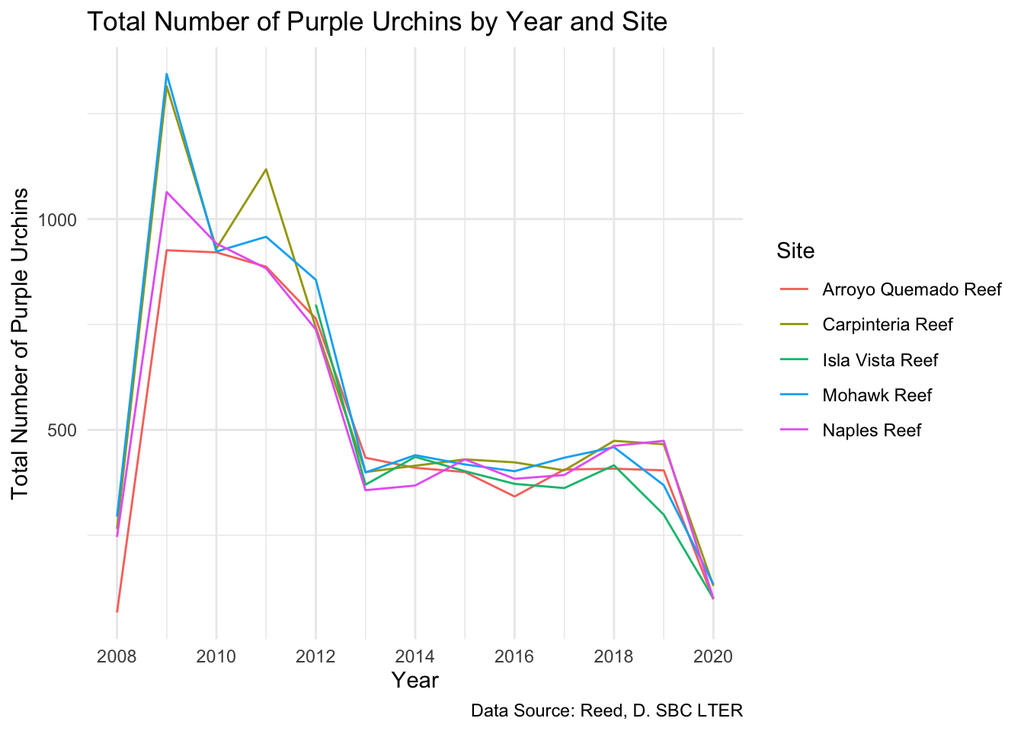

```r
ggplot(data = purple_urchins_summary,
       aes(x = year,
           y = n)) +
  geom_line(aes(color = site_full)) +
  labs(x = "Year",
       y = "Total Number of Purple Urchins",
       title = "Total Number of Purple Urchins by Year and Site",
       color = "Site",
       caption = "Data Source: Reed, D. SBC LTER") +
  scale_x_continuous(breaks = seq(2008, 2020, 2)) +
  theme_minimal()
```

**Takeaways:** This line graph reflects changes in the purple urchin population at different reefs where there has been a decline over the years, including a sharp decline from 2011 to 2013 and from 2019 to 2020. To determine whether the changes in counts by year are reflective of actual changes, there needs to be a control and experimental group for the samples. This will help identify whether the kelp removal has an effect on urchin population decline.